# Case Study Report

05 November, 2022

```r
data_train<-read_csv("data/data-train.csv")
data_test<-read_csv("data/data-test.csv")
```

## Introduction

The objective of this case study is to develop a predictive model to predict the distributions of particle clusters in turbulence from three predictors: fluid turbulence characterized by Reynold’s number $Re$, gravitational acceleration $Fr$, and particle characteristics (size or density which is quantified by Stoke’s number $St$).

Developing an understanding of turbulence is important because the effects of turbulence are present in a wide variety of problems. For example, the distribution of ash in the atmosphere is controlled by atmospheric turbulence, which has many implications for the environment and aviation. Turbulence also controls the population dynamics of planktons, which play an important role in the carbon cycle. On a more cosmological and atmospheric level, turbulence plays a central part in the dispersion of ash in the atmosphere which has many implications for the environment and aviation as well as the thermodynamics of clouds, radiative properties, and the rate at which droplets grow to form rain. The model we have decided to use to predict turbulence is a linear regression with all three variables and interaction terms, shown below:

where $Re_{category}$ is a categorical variable that classifies the training $Re$ into three categories ($Re = 90$ : Low, $Re = 224$ : Medium, $Re = 398$ : High) and $Fr_{transformed}$ is the inverse logit of $Fr$ to handle infinity values present in the data. The model includes interactions between gravitational acceleration and fluid turbulence, and between fluid turbulence and particle characteristics.

## Methodology

### EDA

After loading the data, we performed exploratory data analysis on all three predictors and four moments.

We first noted that the predictor variables `Re` is clustered at fixed values, with `Re` clustering at 90, 224 and 398 (3 levels).

```r
summary(data_train$St)
```

```
##    Min. 1st Qu.  Median    Mean 3rd Qu.    Max.
##  0.0500  0.3000  0.7000  0.8596  1.0000  3.0000
```

```r
summary(data_train$Re)
```

```
##    Min. 1st Qu.  Median    Mean 3rd Qu.    Max.
##    90.0    90.0   224.0   214.5   224.0   398.0
```

```r
summary(data_train$Fr)
```

```
##    Min. 1st Qu.  Median    Mean 3rd Qu.    Max.
##   0.052   0.052   0.300     Inf     Inf     Inf
```

We found that the moments are not only highly correlated,

```r
res<-cor(data_train)
res
```

```
##                     St          Re  Fr R_moment_1 R_moment_2 R_moment_3
## St          1.00000000 -0.03169871 NaN  0.2147681  0.1479257  0.1647465
## Re         -0.03169871  1.00000000 NaN -0.7747206 -0.3932344 -0.3844289
## Fr                 NaN         NaN   1        NaN        NaN        NaN
## R_moment_1  0.21476813 -0.77472058 NaN  1.0000000  0.6298829  0.6217326
## R_moment_2  0.14792571 -0.39323445 NaN  0.6298829  1.0000000  0.9984335
## R_moment_3  0.16474648 -0.38442895 NaN  0.6217326  0.9984335  1.0000000
## R_moment_4  0.18004537 -0.37741773 NaN  0.6150484  0.9946671  0.9988414
##            R_moment_4
## St          0.1800454
## Re         -0.3774177
## Fr                NaN
## R_moment_1  0.6150484
## R_moment_2  0.9946671
## R_moment_3  0.9988414
## R_moment_4  1.0000000
```

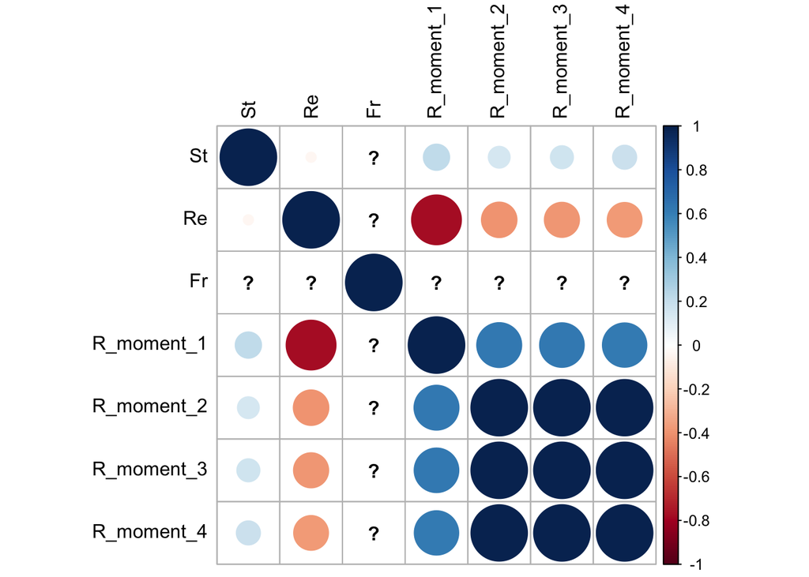

```r
corrplot(res, tl.col ="black")
```

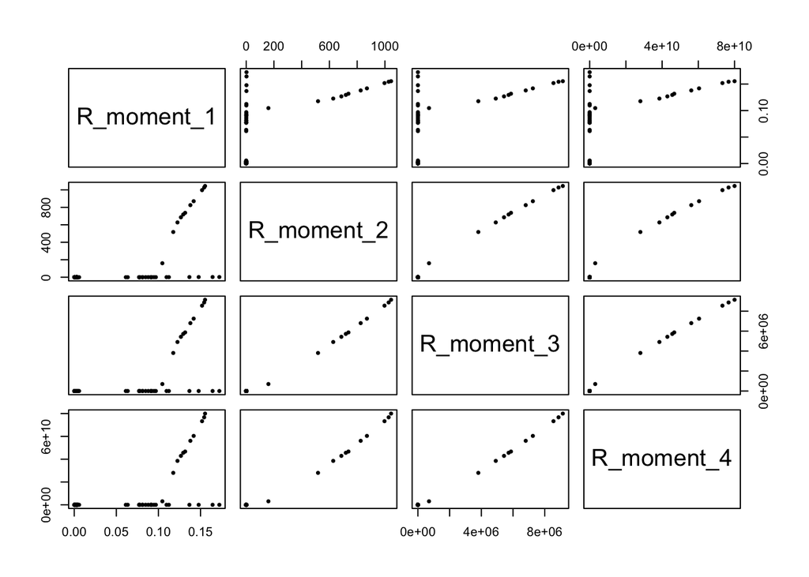

```r
pairs(data_train[4:7], cex = 0.5, pch = 19)
```

```r
library(gridExtra)
```

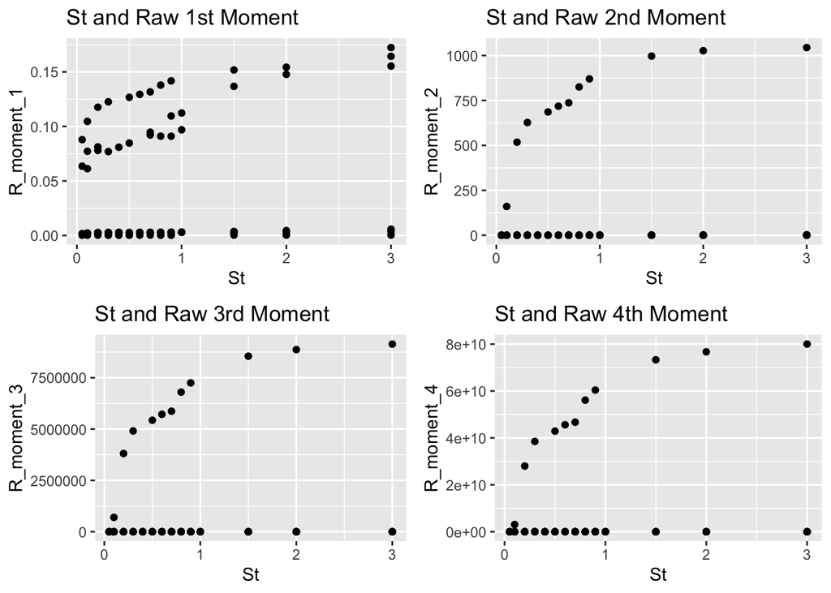

```r
p1 <- ggplot(data = data_train, mapping = aes(x = St, y = R_moment_1)) +
     geom_point() + labs(title = "St and Raw 1st Moment")
p2 <- ggplot(data = data_train, mapping = aes(x = St, y = R_moment_2)) +
     geom_point() + labs(title = "St and Raw 2nd Moment")
p3 <- ggplot(data = data_train, mapping = aes(x = St, y = R_moment_3)) +
     geom_point() + labs(title = "St and Raw 3rd Moment")
p4 <- ggplot(data = data_train, mapping = aes(x = St, y = R_moment_4)) +
     geom_point() + labs(title = "St and Raw 4th Moment")
grid.arrange(p1, p2, p3, p4, nrow = 2)
```

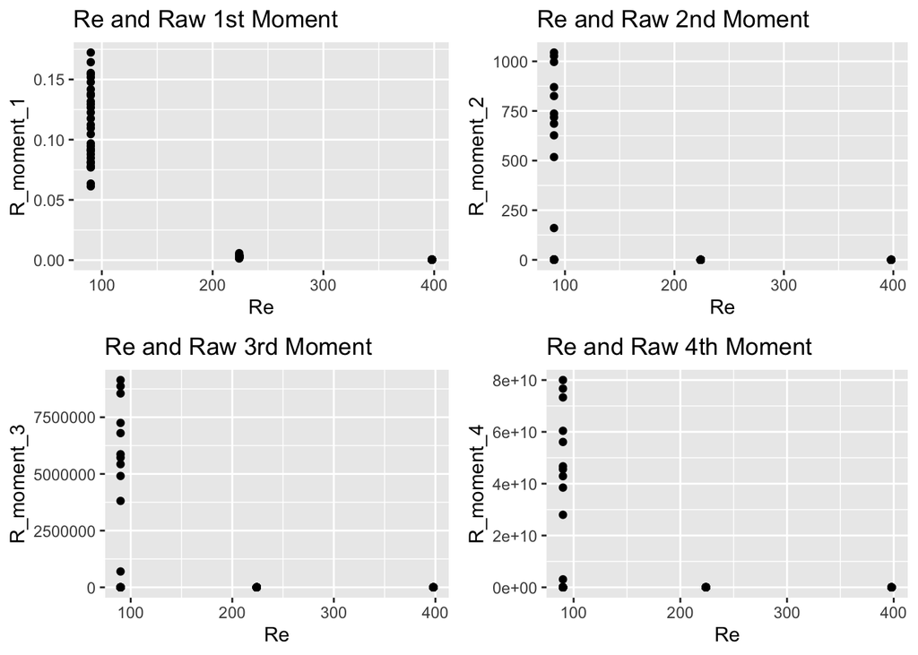

```r
p5 <- ggplot(data = data_train, mapping = aes(x = Re, y = R_moment_1)) +
     geom_point() + labs(title = "Re and Raw 1st Moment")
p6 <- ggplot(data = data_train, mapping = aes(x = Re, y = R_moment_2)) +
     geom_point() + labs(title = "Re and Raw 2nd Moment")
p7 <- ggplot(data = data_train, mapping = aes(x = Re, y = R_moment_3)) +
     geom_point() + labs(title = "Re and Raw 3rd Moment")
p8 <- ggplot(data = data_train, mapping = aes(x = Re, y = R_moment_4)) +
     geom_point() + labs(title = "Re and Raw 4th Moment")
grid.arrange(p5, p6, p7, p8, nrow = 2)
```

Moreover, we noticed that the gravitational acceleration has infinite values, which is problematic. Therefore, we used inverse logit transform on `Fr` to transform the infinity value into a finite value (Inf transformed to 1):

```r
data_train <- data_train %>%
  mutate(Re_category = case_when(Re == 90 ~ "Low", Re==224 ~ "Medium", Re == 398 ~ "High"))%>%
  mutate(Fr_transformed = invlogit(Fr))
```

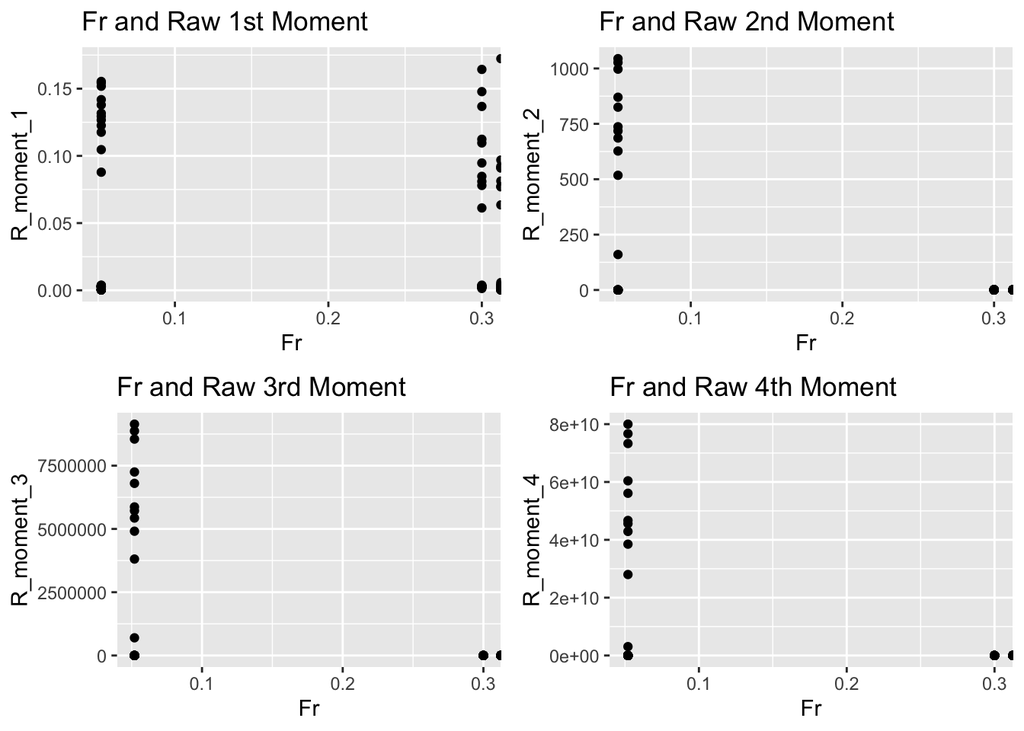

```r
p9 <- ggplot(data = data_train, mapping = aes(x = Fr, y = R_moment_1)) +
     geom_point() + labs(title = "Fr and Raw 1st Moment")
p10 <- ggplot(data = data_train, mapping = aes(x = Fr, y = R_moment_2)) +
     geom_point() + labs(title = "Fr and Raw 2nd Moment")
p11 <- ggplot(data = data_train, mapping = aes(x = Fr, y = R_moment_3)) +
     geom_point() + labs(title = "Fr and Raw 3rd Moment")
p12 <- ggplot(data = data_train, mapping = aes(x = Fr, y = R_moment_4)) +
     geom_point() + labs(title = "Fr and Raw 4th Moment")
grid.arrange(p9, p10, p11, p12, nrow = 2)
```

In order to have better intepretation from the perspective of statistical inference, we convert raw moments to central moments. The first central moment is always 0, so we don’t need to convert it.

```r
data_train <- data_train %>% mutate(C_moment_2 = R_moment_2 - R_moment_1^2,
                                    C_moment_3 = R_moment_3 - 3*R_moment_1*R_moment_2 + 2*(R_moment_1^3),
                                    C_moment_4 = R_moment_4 - 4*R_moment_1*R_moment_3 + 6*(R_moment_1^2)*R_moment_2 - 3*(R_moment_1^4))
```

We then explored shrinkage methods such as ridge regression and lasso. However, since we know that the three predictors are all active so that we do not need predictor selection, so we attempted to fit a ridge regression model:

### Ridge Model

We first build ridge models for the 2nd, 3rd, and 4th central moments.

```r
data_train <- data_train %>%
  mutate(Fr_category = case_when(Fr == 0.052 ~ "Low", Fr == 0.3 ~ "Medium", Fr == Inf ~ "High"))
```

```r
x <- data.matrix(data_train[, c('Re_category', 'St', 'Fr_category')])
```

```r
set.seed(123456)

train <- sample(1:nrow(x), nrow(x)/2)
test <- (-train)
lambda_seq = 10^seq(10, -2, length = 100)
```

```r
y2 <- data_train$C_moment_2
ridge2 <- glmnet(x[train, ], y2[train], alpha = 0, lambda = lambda_seq)
y2.test = y2[test]
```

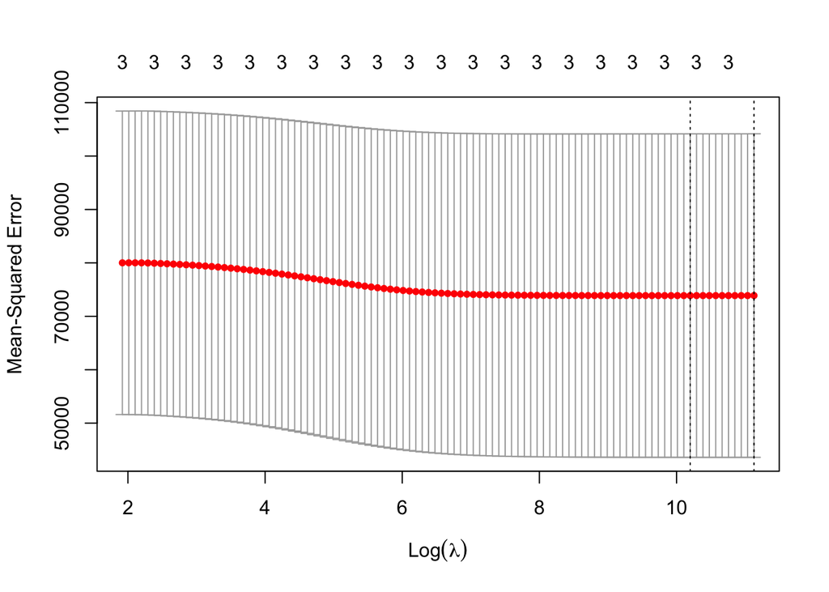

```r
set.seed(123456)
#perform k-fold cross-validation to find optimal lambda value
cv_ridge2 <- cv.glmnet(x[train,], y2[train], alpha = 0, folds = 5)
best_lambda2 <- cv_ridge2$lambda.min
plot(cv_ridge2)
```

```r
ridge.pred2 <- predict(ridge2, s = best_lambda2, newx = x[test,])
rmse_c2 <- sqrt(mean((ridge.pred2 - y2.test)^2))
```

Ridge model for 3rd central moment:

```r
y3 <- data_train$C_moment_3
```

```r
ridge3 <- glmnet(x[train,], y3[train], alpha = 0, lambda = lambda_seq)
```

```r
set.seed(123)
#perform k-fold cross-validation to find optimal lambda value
cv_ridge3 <- cv.glmnet(x[train,], y3[train], alpha = 0, folds = 5)
#find optimal lambda value that minimizes test MSE
best_lambda3 <- cv_ridge3$lambda.min
```

```r
y3.test <- y3[test]
ridge.pred3 <- predict(ridge3, s = best_lambda3, newx = x[test,])
rmse_c3 <- sqrt(mean((ridge.pred3 - y3.test)^2))
```

Ridge model on 4th central moment:

```r
y4 <- data_train$C_moment_4
```

```r
ridge4 <- glmnet(x[train,], y4[train], alpha = 0, lambda = lambda_seq)
```

```r
set.seed(123456)
#perform k-fold cross-validation to find optimal lambda value
cv_ridge4 <- cv.glmnet(x[train,], y4[train], alpha = 0, folds = 5)
#find optimal lambda value that minimizes test MSE
best_lambda4 <- cv_ridge4$lambda.min
```

```r
y4.test <- y4[test]
ridge.pred4 <- predict(ridge4, s = best_lambda4, newx = x[test,])
rmse_c4 <- sqrt(mean((ridge.pred4 - y4.test)^2))
```

```r
RidgeModel <- c("C_M2", "C_M3", "C_M4")
RMSE <- c(rmse_c2, rmse_c3, rmse_c4)

ridgedf <- data.frame(RidgeModel, RMSE) %>% kable()

print(ridgedf)
```

```
##
##
## |RidgeModel |         RMSE|
## |:----------|------------:|
## |C_M2       | 2.560393e+02|
## |C_M3       | 2.128837e+06|
## |C_M4       | 1.799473e+10|
```

The coefficients predicted by ridge:

```r
ridge.test2 <- glmnet(x, y2, alpha = 0)
predict(ridge.test2, type = 'coefficients', s = best_lambda2)
```

```
## 4 x 1 sparse Matrix of class "dgCMatrix"
##                     s1
## (Intercept) 92.5853575
## Re_category -0.3312422
## St           0.4730448
## Fr_category  0.1199465
```

```r
ridge.test3 <- glmnet(x, y3, alpha = 0)
predict(ridge.test3, type = 'coefficients', s = best_lambda3)
```

```
## 4 x 1 sparse Matrix of class "dgCMatrix"
##                     s1
## (Intercept) 755539.299
## Re_category -17151.751
## St           27744.146
## Fr_category   6298.821
```

```r
ridge.test4 <- glmnet(x, y4, alpha = 0)
predict(ridge.test4, type = 'coefficients', s = best_lambda4)
```

```
## 4 x 1 sparse Matrix of class "dgCMatrix"
##                     s1
## (Intercept) 6193034471
## Re_category  -31532416
## St            56975007
## Fr_category   11329501
```

### Linear Model

Since the 1st central moment is always 0, we need to predict 1st raw moment directly.

```r
final_model_M1 <- lm(R_moment_1 ~ St+ Re_category+Fr_transformed+Fr_transformed*Re_category+St*Re_category, data = data_train)
final_model_M2 <- lm(C_moment_2 ~ St+ Re_category+Fr_category+Fr_category*Re_category+St*Re_category, data = data_train)
final_model_M3 <- lm(C_moment_3 ~ St+ Re_category+Fr_category+Fr_category*Re_category+St*Re_category, data = data_train)
final_model_M4 <- lm(C_moment_4 ~ St+ Re_category+Fr_category+Fr_category*Re_category+St*Re_category, data = data_train)
summ(final_model_M1)
```

| Observations | 89 |
| --- | --- |
| Dependent variable | R_moment_1 |
| Type | OLS linear regression |

| F(8,80) | 392.74 |
| --- | --- |
| R² | 0.98 |
| Adj. R² | 0.97 |

|  | Est. | S.E. | t val. | p |
| --- | --- | --- | --- | --- |
| (Intercept) | 0.00 | 0.01 | 0.03 | 0.98 |
| St | 0.00 | 0.00 | 0.02 | 0.98 |
| Re_categoryLow | 0.12 | 0.01 | 12.27 | 0.00 |
| Re_categoryMedium | 0.00 | 0.01 | 0.16 | 0.87 |
| Fr_transformed | 0.00 | 0.01 | 0.01 | 0.99 |
| Re_categoryLow:Fr_transformed | -0.05 | 0.01 | -4.39 | 0.00 |
| Re_categoryMedium:Fr_transformed | 0.00 | 0.01 | 0.05 | 0.96 |
| St:Re_categoryLow | 0.03 | 0.00 | 7.99 | 0.00 |
| St:Re_categoryMedium | 0.00 | 0.00 | 0.23 | 0.82 |

Standard errors: OLS

```r
summ(final_model_M2)
```

| Observations | 89 |
| --- | --- |
| Dependent variable | C_moment_2 |
| Type | OLS linear regression |

| F(10,78) | 43.93 |
| --- | --- |
| R² | 0.85 |
| Adj. R² | 0.83 |

|  | Est. | S.E. | t val. | p |
| --- | --- | --- | --- | --- |
| (Intercept) | 0.01 | 42.26 | 0.00 | 1.00 |
| St | 0.00 | 34.07 | 0.00 | 1.00 |
| Re_categoryLow | -84.76 | 58.31 | -1.45 | 0.15 |
| Re_categoryMedium | -0.02 | 57.24 | -0.00 | 1.00 |
| Fr_categoryLow | -0.00 | 51.11 | -0.00 | 1.00 |
| Fr_categoryMedium | 0.00 | 43.67 | 0.00 | 1.00 |
| Re_categoryLow:Fr_categoryLow | 672.20 | 69.90 | 9.62 | 0.00 |
| Re_categoryMedium:Fr_categoryLow | 0.26 | 66.50 | 0.00 | 1.00 |
| Re_categoryLow:Fr_categoryMedium | -26.49 | 66.33 | -0.40 | 0.69 |
| Re_categoryMedium:Fr_categoryMedium | NA | NA | NA | NA |
| St:Re_categoryLow | 108.98 | 40.99 | 2.66 | 0.01 |
| St:Re_categoryMedium | 0.06 | 41.60 | 0.00 | 1.00 |

Standard errors: OLS

```r
summ(final_model_M3)
```

| Observations | 89 |
| --- | --- |
| Dependent variable | C_moment_3 |
| Type | OLS linear regression |

| F(10,78) | 37.83 |
| --- | --- |
| R² | 0.83 |
| Adj. R² | 0.81 |

|  | Est. | S.E. | t val. | p |
| --- | --- | --- | --- | --- |
| (Intercept) | 0.11 | 375171.01 | 0.00 | 1.00 |
| St | 0.03 | 302414.16 | 0.00 | 1.00 |
| Re_categoryLow | -802591.11 | 517672.10 | -1.55 | 0.13 |
| Re_categoryMedium | -6.72 | 508185.65 | -0.00 | 1.00 |
| Fr_categoryLow | -0.05 | 453727.64 | -0.00 | 1.00 |
| Fr_categoryMedium | 1.72 | 387648.28 | 0.00 | 1.00 |
| Re_categoryLow:Fr_categoryLow | 5480396.14 | 620493.46 | 8.83 | 0.00 |
| Re_categoryMedium:Fr_categoryLow | 43.47 | 590331.45 | 0.00 | 1.00 |
| Re_categoryLow:Fr_categoryMedium | -252727.28 | 588878.64 | -0.43 | 0.67 |
| Re_categoryMedium:Fr_categoryMedium | NA | NA | NA | NA |
| St:Re_categoryLow | 1024595.14 | 363851.44 | 2.82 | 0.01 |
| St:Re_categoryMedium | 7.98 | 369314.66 | 0.00 | 1.00 |

Standard errors: OLS

```r
summ(final_model_M4)
```

| Observations | 89 |
| --- | --- |
| Dependent variable | C_moment_4 |
| Type | OLS linear regression |

| F(10,78) | 33.95 |
| --- | --- |
| R² | 0.81 |
| Adj. R² | 0.79 |

|  | Est. | S.E. | t val. | p |
| --- | --- | --- | --- | --- |
| (Intercept) | 2.26 | 3284583507.40 | 0.00 | 1.00 |
| St | 0.51 | 2647604797.76 | 0.00 | 1.00 |
| Re_categoryLow | -7406386658.12 | 4532165802.79 | -1.63 | 0.11 |
| Re_categoryMedium | -1104.60 | 4449112925.67 | -0.00 | 1.00 |
| Fr_categoryLow | -1.15 | 3972338652.05 | -0.00 | 1.00 |
| Fr_categoryMedium | 295.58 | 3393820678.67 | 0.00 | 1.00 |
| Re_categoryLow:Fr_categoryLow | 44951148789.73 | 5432356260.03 | 8.27 | 0.00 |
| Re_categoryMedium:Fr_categoryLow | 6402.26 | 5168290949.76 | 0.00 | 1.00 |
| Re_categoryLow:Fr_categoryMedium | -2332224063.47 | 5155571748.15 | -0.45 | 0.65 |
| Re_categoryMedium:Fr_categoryMedium | NA | NA | NA | NA |
| St:Re_categoryLow | 9454961858.80 | 3185481783.58 | 2.97 | 0.00 |
| St:Re_categoryMedium | 1176.71 | 3233311754.86 | 0.00 | 1.00 |

Standard errors: OLS

Here we perform a 5-fold cross validation on the model. We chose 5 folds over 10 because the limited data available.

```r
set.seed(123456)
train.control <- trainControl(method = "cv", number = 5)
M1_cv <- train(R_moment_1 ~ St+ Re_category+Fr_transformed+Fr_transformed*Re_category+St*Re_category, data = data_train, method = "lm", trControl = train.control)
M2_cv <- train(C_moment_2 ~ St+ Re_category+Fr_category+Fr_category*Re_category+St*Re_category, data = data_train, method = "lm", trControl = train.control)
M3_cv <- train(C_moment_3 ~ St+ Re_category+Fr_category+Fr_category*Re_category+St*Re_category, data = data_train, method = "lm", trControl = train.control)
M4_cv <- train(C_moment_4 ~ St+ Re_category+Fr_category+Fr_category*Re_category+St*Re_category, data = data_train, method = "lm", trControl = train.control)
```

```r
library(knitr)
M1_metrics <- M1_cv$results %>% select(c("RMSE", "Rsquared", "MAE"))
M2_metrics <- M2_cv$results %>% select(c("RMSE", "Rsquared", "MAE"))
M3_metrics <- M3_cv$results %>% select(c("RMSE", "Rsquared", "MAE"))
M4_metrics <- M4_cv$results %>% select(c("RMSE", "Rsquared", "MAE"))

cv_df <- merge(M1_metrics, M2_metrics, by=c("RMSE", "Rsquared", "MAE"), all = TRUE)
cv_df2 <- merge(cv_df, M3_metrics, by=c("RMSE", "Rsquared", "MAE"), all = TRUE)
total_cv <- merge(cv_df2, M4_metrics, by=c("RMSE", "Rsquared", "MAE"), all = TRUE)
total_cv <- total_cv %>% mutate(Model = c('R_M1', 'C_M2', 'C_M3', 'C_M4')) %>% relocate(Model, .before = RMSE)
total_cv %>% kable(digits = 3)
```

| Model | RMSE | Rsquared | MAE |
| --- | --- | --- | --- |
| R_M1 | 1.000000e-02 | 0.978 | 5.000000e-03 |
| C_M2 | 1.110450e+02 | 0.882 | 4.657600e+01 |
| C_M3 | 9.534512e+05 | 0.820 | 3.988096e+05 |
| C_M4 | 7.653045e+09 | 0.808 | 3.356711e+09 |

We can see that the linear model performs better than the ridge model over all, so we ’ll use the linear model for prediction.

Moreover, it is simpler to interpret the inference result with the linear model. So we can also use the linear model for interpreting the relationship between variables.

## Results

We made predictions on the hold-out set in data-test.csv, and generated a csv file containing the predictions for the first, second, third and fourth moments.

```r
data_test_transformed <- data_test %>%
  mutate(Re_category = case_when(Re == 90 ~ "Low", Re==224 ~ "Medium", Re == 398 ~ "High"))%>%
  mutate(Fr_transformed = invlogit(Fr))%>%
  mutate(Fr_category = case_when(Fr == 0.052 ~ "Low", Fr == 0.3 ~ "Medium", Fr == Inf ~ "High"))%>%
  mutate(Predicted_M1 = predict(final_model_M1, .))%>%
  mutate(Predicted_M2 = predict(final_model_M2, .))%>%
  mutate(Predicted_M3 = predict(final_model_M3, .))%>%
  mutate(Predicted_M4 = predict(final_model_M4, .))

data_predicted_output <- data_test_transformed%>%select(St, Re, Re_category, Fr,Fr_transformed,Fr_category, Predicted_M1, Predicted_M2, Predicted_M3, Predicted_M4)%>%
  mutate(Predicted_R_M1 = predict(final_model_M1, .))%>%
  mutate(Predicted_C_M2 = predict(final_model_M2, .))%>%
  mutate(Predicted_C_M3 = predict(final_model_M3, .))%>%
  mutate(Predicted_C_M4 = predict(final_model_M4, .))%>%
  mutate(Predicted_R_M2 = Predicted_C_M2 + (Predicted_R_M1)^2) %>%
  mutate(Predicted_R_M3 = Predicted_C_M3 + 3*Predicted_R_M1*Predicted_R_M2 - 2*(Predicted_R_M1)^3) %>%
  mutate(Predicted_R_M4 = Predicted_C_M4 + 4*Predicted_R_M1*Predicted_R_M3 - 6*(Predicted_R_M1)^2*Predicted_R_M2 + 3*(Predicted_R_M1)^4)

data_predicted_output <- data_predicted_output%>%select(St, Re, Fr, Predicted_R_M1, Predicted_R_M2, Predicted_R_M3, Predicted_R_M4)

write.csv(data_predicted_output,"data-predict.csv", row.names = FALSE)
data_predicted_output %>% kable(digits = 5)
```

| St | Re | Fr | Predicted_R_M1 | Predicted_R_M2 | Predicted_R_M3 | Predicted_R_M4 |
| --- | --- | --- | --- | --- | --- | --- |
| 0.05 | 398 | 0.052 | 0.00027 | 0.00345 | 6.253000e-02 | 1.132750e+00 |
| 0.20 | 398 | 0.052 | 0.00028 | 0.00366 | 6.652000e-02 | 1.208660e+00 |
| 0.70 | 398 | 0.052 | 0.00031 | 0.00436 | 7.981000e-02 | 1.461710e+00 |
| 1.00 | 398 | 0.052 | 0.00033 | 0.00479 | 8.779000e-02 | 1.613540e+00 |
| 0.10 | 398 | Inf | 0.00033 | 0.00528 | 1.103300e-01 | 2.311810e+00 |
| 0.60 | 398 | Inf | 0.00037 | 0.00599 | 1.236200e-01 | 2.564870e+00 |
| 1.00 | 398 | Inf | 0.00039 | 0.00655 | 1.342500e-01 | 2.767320e+00 |
| 1.50 | 398 | Inf | 0.00043 | 0.00725 | 1.475400e-01 | 3.020390e+00 |
| 3.00 | 398 | Inf | 0.00053 | 0.00937 | 1.874200e-01 | 3.779600e+00 |
| 3.00 | 224 | 0.300 | 0.00476 | 0.18816 | 1.913936e+01 | 2.725254e+03 |
| 0.10 | 224 | Inf | 0.00247 | -0.00485 | -5.809620e+00 | -9.846780e+02 |
| 0.50 | 224 | Inf | 0.00282 | 0.02140 | -2.605880e+00 | -5.137632e+02 |
| 0.40 | 90 | 0.052 | 0.10642 | 631.05365 | 5.087845e+06 | 4.132891e+10 |
| 1.00 | 90 | 0.052 | 0.12325 | 696.44918 | 5.702658e+06 | 4.700254e+10 |
| 0.05 | 90 | 0.300 | 0.09339 | -105.78589 | -1.004116e+06 | -9.266237e+09 |
| 0.30 | 90 | 0.300 | 0.10040 | -78.53800 | -7.479617e+05 | -6.902422e+09 |
| 0.60 | 90 | 0.300 | 0.10882 | -45.84041 | -4.405744e+05 | -4.065825e+09 |
| 0.80 | 90 | 0.300 | 0.11442 | -24.04194 | -2.356487e+05 | -2.174749e+09 |
| 0.40 | 90 | Inf | 0.08092 | -41.15255 | -3.927629e+05 | -3.624529e+09 |
| 0.50 | 90 | Inf | 0.08373 | -30.25348 | -2.903010e+05 | -2.679003e+09 |
| 0.60 | 90 | Inf | 0.08653 | -19.35439 | -1.878389e+05 | -1.733475e+09 |
| 1.50 | 90 | Inf | 0.11177 | 78.73811 | 7.343281e+05 | 6.776384e+09 |
| 2.00 | 90 | Inf | 0.12579 | 133.23450 | 1.246650e+06 | 1.150416e+10 |

The predicted raw 1st moement is directly predicted from the raw mean, and the other three moments are converted from predicted central moments.

Major observations from the results:

- When Re and Fr are both small, the predicted turbulence have very large variance.